# Project Python Foundations: FoodHub Data Analysis

#### Observation for Question 6 - Summary of Observations (for individual columns):

1. order_id (identifier)

   a. All order_id values are unique (unique IDs = total rows), so there are no duplicates.

   b. This column is an identifier only (not a measurable variable) — not used for stats like mean/median or distribution plots.
2. customer_id (identifier)

   a. There are 1,200 unique customers across 1,898 orders, meaning some customers placed multiple orders.

   b. About 36.8% of orders are from repeat customers, showing good customer retention.

   c. Distribution is right-skewed: most customers place only 1 order, some placed 2–5 orders, and a few customers placed many orders.

   d. Most active customer placed 13 orders.

   e. customer_id is categorical in nature (an integer label), used for grouping/counting, not a numerical variable used for calculations like mean or median.
3. restaurant_name (categorical)

   a. There are 178 unique restaurants.

   b. Distribution is highly skewed (long tail): a few restaurants receive most of the orders, while most of the restaurants have very few orders.

   c. Around 54% of restaurants have three or fewer orders, while the remaining 46% handle the majority of total order volume.

   d. Top-performing restaurants include Shake Shack (≈219), The Meatball Shop (≈132), Blue Ribbon Sushi (≈119).

   Implication: Focus marketing and app promotions on two groups:

   (i) Top-performing restaurants — Work closely with the restaurants that already get the most orders. Give them more visibility in the app and run joint marketing campaigns to maintain their momentum and further increase engagement and revenue.

   (ii) Low-performing restaurants — Help smaller restaurants grow by offering targeted promotions and visibility boosts to attract new customers and improve overall order distribution. (Nurture the long-tail segment with promos.)
4. cuisine_type (categorical)

   b. The distribution is right-skew - a small number of popular cuisines (American, Italian, Japanese) dominate total orders, while most others (Mediterranean, Korean, Mexican, etc.) have relatively few orders and are considered niche.

   Implication: i. Ensure there is enough restaurant availability and delivery capacity for high-demand cuisines like American and Italian. ii. At the same time, use targeted promotions or personalized marketing campaigns to encourage more customers to try less popular cuisines and increase variety in customer preferences.
5. day_of_the_week (categorical)

   a. Around 71% of orders are placed on weekends and 29% on weekdays.

   b. This means demand is much higher on weekends.

   Implication: i. Have more kitchen staff, delivery drivers, and customer support available on weekends.

   ii. Run weekend promotions and marketing campaigns, such as “Weekend Feast – 20% Off” or Friday/Saturday app notifications to capture peak demand.
6. rating (categorical / ordinal)

   a. About 39% of orders have “Not given” ratings, meaning many customers skip feedback.

   b. Among rated orders, most ratings are 5★, followed by 4★, showing high customer satisfaction.

   Implication: i. Encourage more ratings by adding reminders or small incentives like reward points.

   ii. Promote high-rated restaurants in marketing or app listings to build customer trust.
7. cost_of_the_order (numeric)

   a. The typical order cost ranges from approximately $4.47 to $35.41.

   b. Mean ≈ $16.5, Median ≈ $14.1 — slightly right-skewed due to a few expensive orders.

   Implication: i. Offer combo meals or add-on suggestions (like “add a drink for $2”) to increase average order value. ii. Track high-spending customers, learn their preferences, and keep them loyal through rewards or special offers.
8. food_preparation_time (numeric)

   a. Preparation times range between 20–35 minutes for most orders.

   b. The mean and median are both around 27 minutes, which shows that the data is fairly symmetric — most restaurants take about the same time to prepare food, indicating consistent preparation times.

   c. There are no major outliers, meaning preparation is steady across restaurants with no big variation or unusual delays in the process.

   Implication: Kitchens are working efficiently and consistently. I recommend continuing with the same preparation processes to maintain stability, prevent long delays, and ensure food is ready on time.
9. delivery_time (numeric)

   a. Delivery times range between 15–33 minutes for most orders.

   b. Mean ≈ 24 minutes, Median ≈ 25 minutes — most deliveries take about the same time, with a small number slightly faster.

   Implication: Delivery operations are reliable, predictable, and consistent. Focus on route optimization and proper staffing during busy peak hours to reduce delays and maintain on-time delivery performance.

**Overall Summary**: Most orders come from a few popular restaurants and cuisines, especially on weekends, and customers are generally satisfied. Food preparation and delivery are consistent and reliable. These insights can help businesses plan marketing, staffing, and promotions more effectively to keep customers happy and support steady growth.

### **Question 7**: Which are the top 5 restaurants in terms of the number of orders received? [1 mark]

```
Top 5 Restaurants by Number of Orders:

restaurant_name
Shake Shack                  219
The Meatball Shop            132
Blue Ribbon Sushi            119
Blue Ribbon Fried Chicken     96
Parm                          68
Name: count, dtype: int64
```

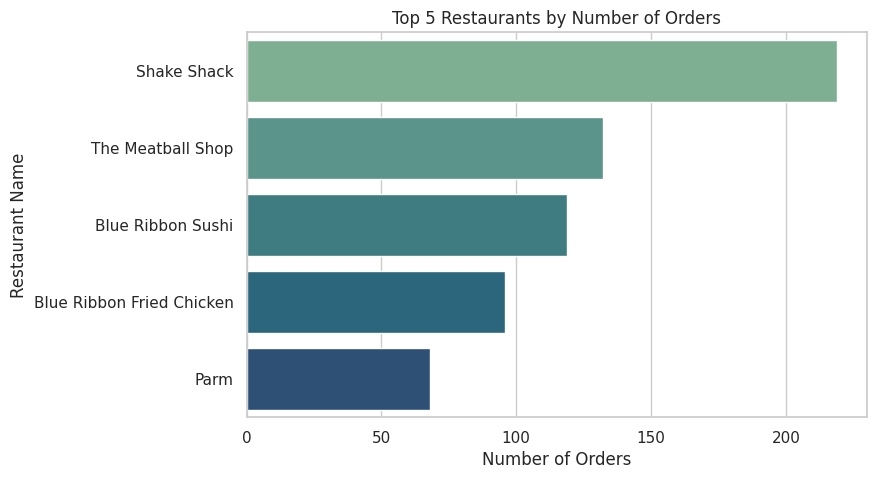

```python
# Question 7: Which are the top 5 restaurants in terms of the number of orders received?


# Step1: Use value_counts() to count total orders for each restaurant
# value_counts() returns the count of unique categories in descending order (highest count first/most frequent first).
# The index represents each unique category, and the corresponding value shows how many times it appears.
top5_restaurants = df['restaurant_name'].value_counts().head(5)

# Step 2: Display the result
print("Top 5 Restaurants by Number of Orders:\n")
print(top5_restaurants)

# Step 3 (Optional): Visualize the top 5 restaurants using a horizontal bar chart
# plt.figure(figsize=(8,5)) sets the figure size (8 inches wide x 5 inches tall).
plt.figure(figsize=(8,5))

# sns.barplot() draws bars for the restaurants.
# x = number of orders (values)
# y = restaurant names (index)
# hue = restaurant names (to give different colors)
# palette = "crest" provides a pleasant color gradient.
# legend = False hides the redundant legend.
sns.barplot(x=top5_restaurants.values, y=top5_restaurants.index, hue=top5_restaurants.index, palette="crest", legend=False)

# Step 4: Add labels and title for clarity
plt.title('Top 5 Restaurants by Number of Orders')
plt.xlabel('Number of Orders')
plt.ylabel('Restaurant Name')

# Step 5: Show the plot
plt.show()
```

#### Observation for Question 7 — Top 5 Restaurants by Number of Orders

1. The dataset shows that a few restaurants dominate the total order volume. The top 5 restaurants are:

   ```
    Shake Shack (≈ 219 orders)

    The Meatball Shop (≈ 132 orders)

    Blue Ribbon Sushi (≈ 119 orders)

    Blue Ribbon Fried Chicken (≈ 96 orders)

    Parm (≈ 68 orders)
   ```

2. These top 5 restaurants show that most customers prefer to order from only a few well-known restaurants. Popular restaurants receive a large share of all total orders, while most of the other restaurants get far fewer orders.
3. The bar chart confirms a right-skewed distribution — a small number of restaurants receive most of the orders, while the majority receive only a few.

Business implication: i. The company should continue promoting and partnering with these high-performing restaurants to maintain customer engagement. ii. At the same time, it can support low-performing restaurants with targeted promotions and visibility boosts to balance order distribution.

### **Question 8**: Which is the most popular cuisine on weekends? [1 mark]

```
Cuisine Orders on Weekends:

cuisine_type
American          415
Japanese          335
Italian           207
Chinese           163
Mexican            53
Indian             49
Middle Eastern     32
Mediterranean      32
Thai               15
French             13
Korean             11
Southern           11
Spanish            11
Vietnamese          4
Name: count, dtype: int64

Most popular cuisine on weekends: American (415 orders)
```

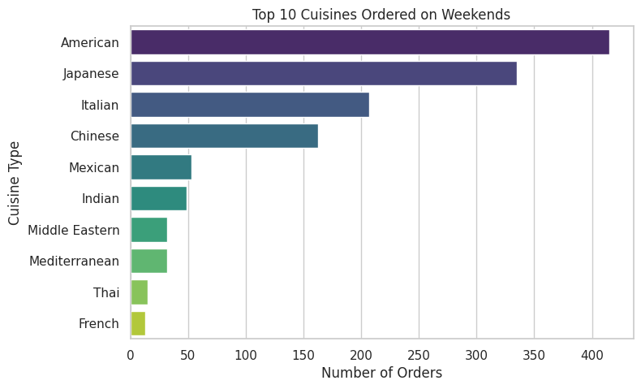

```python
# Question 8: Which is the most popular cuisine on weekends?

# Step 1: Filter the dataset for weekend orders only
# 'day_of_the_week' column contains categories like 'Weekday' and 'Weekend'.
# This filters the dataframe (df) to include only rows where day_of_the_week == 'Weekend'.
weekend_orders = df[df['day_of_the_week'] == 'Weekend']

# Step 2: Count number of orders per cuisine type on weekends
# value_counts() gives the frequency of each cuisine (in descending order — most popular first).
weekend_cuisine_counts = weekend_orders['cuisine_type'].value_counts()
print("Cuisine Orders on Weekends:\n")
print(weekend_cuisine_counts)

# Step 3: Identify the most popular cuisine
# idxmax() returns the index (cuisine name) with the highest count.
# max() returns the actual highest number of orders.
most_popular_cuisine_weekend = weekend_cuisine_counts.idxmax() # American
most_popular_count = weekend_cuisine_counts.max() # 415 orders
print(f"\nMost popular cuisine on weekends: {most_popular_cuisine_weekend} ({most_popular_count} orders)")

# # Step 4 (Optional): Visualize top 10 cuisines ordered on weekends
# Creates a horizontal bar chart showing the top 10 cuisines by weekend order count.
plt.figure(figsize=(8,5))
sns.barplot(
    x=weekend_cuisine_counts.head(10).values,      # X-axis = number of orders
    y=weekend_cuisine_counts.head(10).index,       # Y-axis = cuisine names
    hue=weekend_cuisine_counts.head(10).index,     # Color palette for better visuals
    palette="viridis",                             # Hide redundant legend
    legend=False
)

# Step 5: Add labels and title for clarity
plt.title('Top 10 Cuisines Ordered on Weekends')
plt.xlabel('Number of Orders')
plt.ylabel('Cuisine Type')

# Step 6: Display the plot
plt.show()
```

#### Observations for Question 8 – Most Popular Cuisine on Weekends

Business Implication

i. The company should ensure there are enough restaurants and delivery resources for high-demand cuisines such as American and Italian during weekends.

ii. At the same time, FoodHub can boost sales of lesser-ordered cuisines by running weekend combo deals, limited-time discounts, or “Try Something New” promotions to encourage customers to explore more variety.

### **Question 9**: What percentage of the orders cost more than 20 dollars? [2 marks]

```python
# Question 9: What percentage of the orders cost more than $20?

# Step 1: Count the total number of orders in the dataset
# len(df) returns the total number of rows (each row = one order)
total_orders = len(df)

# Step 2: Count how many orders have a cost greater than $20
# df['cost_of_the_order'] > 20 creates a Boolean filter (True for orders > $20)
# df[...] applies this filter to return only rows where the condition is True
# shape[0] gives the number of such rows (count of orders > $20)
orders_above_20 = df[df['cost_of_the_order'] > 20].shape[0]

# Step 3: Calculate the percentage of orders costing more than $20
# Divide the count of expensive orders by total orders and multiply by 100 to get %
percentage_above_20 = (orders_above_20 / total_orders) * 100

# Step 4: Display the results
print(f"Total Orders: {total_orders}")
print(f"Orders costing more than $20: {orders_above_20}")
print(f"Percentage of orders costing more than $20: {percentage_above_20:.2f}%")
```

```
Total Orders: 1898
Orders costing more than $20: 555
Percentage of orders costing more than $20: 29.24%
```

#### Observations for Question 9 — Orders Costing More Than $20

Business Implication

i. FoodHub can offer combo deals or add-on suggestions to encourage customers to increase their average order value beyond $20.

ii. Create tiered marketing strategies, such as bundle promotions for low-cost customers and loyalty rewards for high-value spenders, to maximize both customer satisfaction and revenue growth.

### **Question 10**: What is the mean order delivery time? [1 mark]

```python
# Question 10: What is the mean order delivery time?

# Step 1: Calculate the mean (average) delivery time across all orders
# The .mean() function computes the arithmetic mean for the 'delivery_time' column.
# It adds up all delivery times and divides by the total number of orders.
mean_delivery_time = df['delivery_time'].mean()

# Step 2: Display the result
# :.2f formats the number to two decimal places for a clean output (e.g., 24.36 -> 24.36 minutes)
print(f"Mean order delivery time: {mean_delivery_time:.2f} minutes")
```

```
Mean order delivery time: 24.16 minutes
```

#### Observations for Question 10:

1. The average (mean) delivery time across all orders is approximately 24 minutes.
2. This shows that FoodHub’s delivery process is generally efficient and consistent, with most orders delivered within a short time window.

Business Implication:

i. FoodHub should continue maintaining this efficient delivery performance, as quick delivery improves customer satisfaction and repeat business.

ii. It can also use this benchmark (≈24 minutes) to monitor future performance and identify delays caused by distance, peak hours, or traffic.

### **Question 11:** The company has decided to give 20% discount vouchers to the top 3 most frequent customers. Find the IDs of these customers and the number of orders they placed. [1 mark]

```
Top 3 Most Frequent Customers (eligible for 20% discount vouchers):

Customer ID  |  Number of Orders
----------------------------------
52832        |  13
47440        |  10
83287        |  9
```

[figure not shown]

```python
# Question 11: Top 3 Most Frequent Customers (eligible for 20% discount vouchers)

# Step 1: Count how many orders each customer has placed
# value_counts() counts the occurrences of each unique customer_id
# It returns a Series sorted in descending order (most frequent customers first)
customer_order_counts = df['customer_id'].value_counts()

# Step 2: Extract the top 3 customers with the highest number of orders
# head(3) selects only the first three rows (top 3 customers)
top3_customers = customer_order_counts.head(3)

# Step 3: Display the result
# These top 3 customers (by order frequency) are eligible for 20% discount vouchers.
# The index of 'top3_customers' represents the Customer IDs,
# and the values represent how many orders each customer has placed.
print("Top 3 Most Frequent Customers (eligible for 20% discount vouchers):\n")
print("Customer ID  |  Number of Orders")
print("----------------------------------")

# Loop through each customer ID and print results in a neatly formatted table
for customer_id, order_count in top3_customers.items():

    #Print the customer ID, left-aligned in a space that’s 12 characters wide.”
    print(f"{customer_id:<12} |  {order_count}")

# Step 4 (Optional): Visualize the top 3 customers using a horizontal bar plot
# sns.barplot() creates a bar chart showing number of orders for each of the top 3 customers
# x = number of orders (values)
# y = customer IDs (index)
# hue = customer IDs (to color each bar differently)
# palette = "crest" adds a visually appealing gradient color palette
# legend=False hides the redundant legend since labels are already shown
plt.figure(figsize=(6,4))
sns.barplot(x=top3_customers.values, y=top3_customers.index, hue=top3_customers.index, palette="crest", legend=False)

# Step 5: Add title and labels for clarity
plt.title('Top 3 Most Frequent Customers')
plt.xlabel('Number of Orders')
plt.ylabel('Customer ID')

# Step 6: Show the plot
plt.show()
```

#### Observations for Question 11 — Top 3 Most Frequent Customers

The top 3 most frequent customers (eligible for 20% discount vouchers) are:

[output not shown]

Insights:

1. These top 3 customers represent FoodHub’s most loyal and high-value users, placing multiple repeat orders.
2. Offering 20% discount vouchers is an effective way to reward loyalty and encourage continued engagement.
3. This pattern highlights that repeat customers significantly contribute to total order volume and overall platform revenue.

Business Implication

i. FoodHub should continue rewarding these loyal customers with the 20% discount vouchers, as it strengthens customer relationships and improves retention.

ii. Additionally, the company can analyze their order patterns (e.g., favorite cuisines, order timing, or spending habits) to understand what drives loyalty — and apply those insights to attract more repeat customers.

### **Question 12**: Perform a multivariate analysis to explore relationships between the important variables in the dataset. (It is a good idea to explore relations between numerical variables as well as relations between numerical and categorical variables) [10 marks]

```
Correlation Matrix between Numeric Variables:
---------------------------------------------
                       cost_of_the_order  food_preparation_time  delivery_time
cost_of_the_order               1.000000               0.041527      -0.029949
food_preparation_time           0.041527               1.000000       0.011094
delivery_time                  -0.029949               0.011094       1.000000

 Visualize the correlations using a heatmap:
--------------------------------------------
```

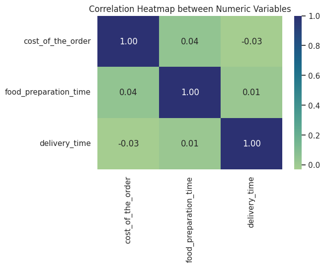

```
VISUALIZE THE RELATIONSHIP BETWEEN TWO NUMERIC VARIABLES USING SCATTERPLOT:
---------------------------------------------------------------------------
```

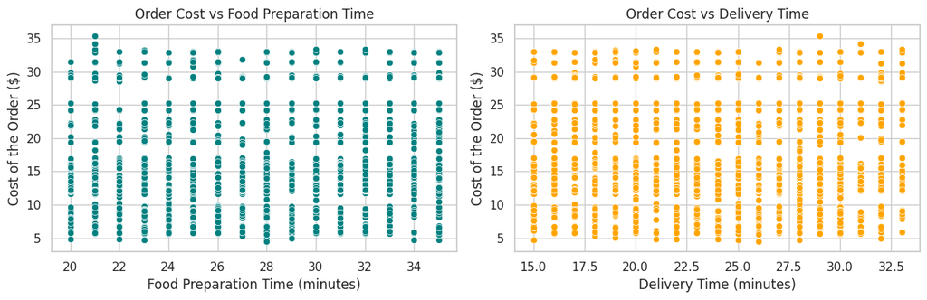

```
VISUALIZE THE RELATIONSHIP BETWEEN ONE NUMERIC VARIABLE AND ACROSS CATEGORICAL GROUPS USING BOXPLOT:
---------------------------------------------------------------------------------------------------
```

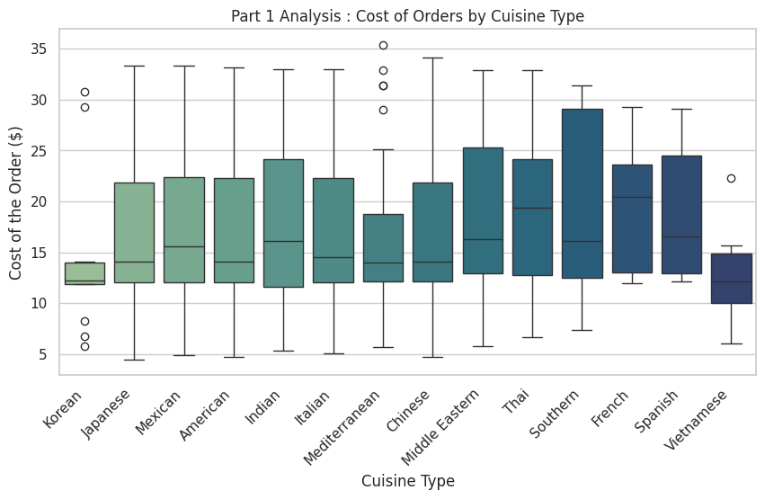

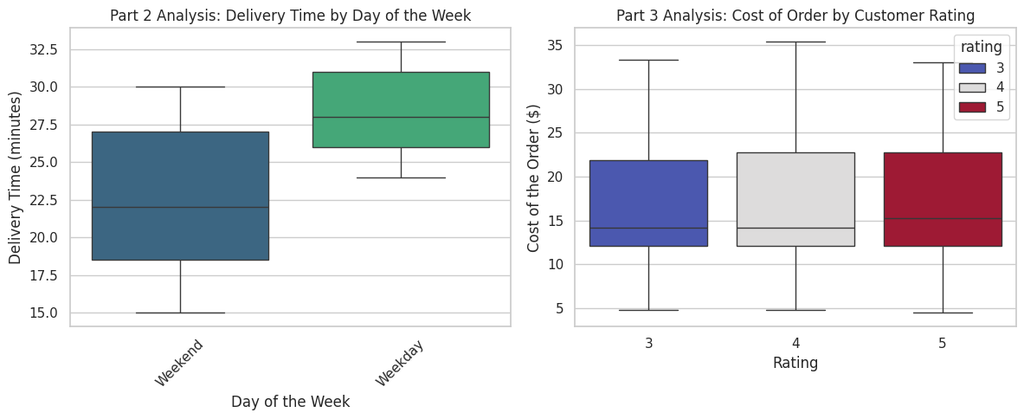

```python
# Question 12: Multivariate Analysis - Explore relationships between important variables

# -------------------------------------------------------------------------
# Step 1: Select relevant numerical columns for correlation analysis
# -------------------------------------------------------------------------
numeric_cols = ['cost_of_the_order', 'food_preparation_time', 'delivery_time']

# Compute correlation matrix between numeric variables
# .corr() calculates pairwise correlation (how strongly two variables move together)
# Values range from:
#   +1 = strong positive correlation (both increase together)
#   -1 = strong negative correlation (one increases, other decreases)
#    0 = no correlation
corr_matrix = df[numeric_cols].corr()

# Display correlation matrix
print("Correlation Matrix between Numeric Variables:")
print("---------------------------------------------")
print(corr_matrix)

# -------------------------------------------------------------------------
# Step 2: Visualize the correlations using a heatmap
# -------------------------------------------------------------------------
print("\n Visualize the correlations using a heatmap:")
print("--------------------------------------------")
plt.figure(figsize=(6, 4))
sns.heatmap(corr_matrix, annot=True, cmap='crest', fmt=".2f")
plt.title("Correlation Heatmap between Numeric Variables")
plt.show()

# -----------------------------------------------------------------------------------
# Step 3: Explore relationship between cost and time variables (side-by-side plots)
# -----------------------------------------------------------------------------------
# Scatter plots are used here to visualize the relationship between two numeric variables.
# Scatterplots shows if higher-cost orders take longer to prepare or delivery.

# Interpretation (left-plot - Food Preparation Time vs Cost):
# Each dot represents one order.
# If points form an upward trend, it suggests that longer preparation times
# might be associated with higher-cost (more complex or premium) meals.

# Interpretation (right-plot - Delivery Time vs Cost):
# This plot checks if higher-cost orders tend to take longer to deliver.
# For example, distant deliveries or larger orders might correlate with longer delivery times.
# ------------------------------------------------------------------------------

print("\n\033[1mVISUALIZE THE RELATIONSHIP BETWEEN TWO NUMERIC VARIABLES USING SCATTERPLOT:\033[0m")
print("---------------------------------------------------------------------------")

# Create a figure with 1 row and 2 columns (side-by-side scatterplot comparison)
# 'fig' is the overall figure, and 'axes' is an array containing two subplots.
# figsize=(12, 4) sets the overall width and height of the figure in inches.
fig, axes = plt.subplots(1, 2, figsize=(12, 4))

# -------------------------------------------------------------------------
# Left plot — Food Preparation Time vs Cost
# -------------------------------------------------------------------------
# Plot a scatterplot showing how food preparation time relates to order cost.
# 'ax=axes[0]' tells seaborn to draw this plot in the first (left) subplot.
sns.scatterplot(
    x='food_preparation_time',
    y='cost_of_the_order',
    data=df,
    color='teal',
    ax=axes[0]
)

# Add labels and title for the left scatterplot
axes[0].set_title("Order Cost vs Food Preparation Time")
axes[0].set_xlabel("Food Preparation Time (minutes)")
axes[0].set_ylabel("Cost of the Order ($)")

# -------------------------------------------------------------------------
# Right plot — Delivery Time vs Cost
# -------------------------------------------------------------------------
# Plot another scatterplot showing how delivery time relates to order cost.
# 'ax=axes[1]' draws this on the second (right) subplot.
sns.scatterplot(
    x='delivery_time',
    y='cost_of_the_order',
    data=df,
    color='orange',
    ax=axes[1]
)

# Add labels and title for the right scatterplot
axes[1].set_title("Order Cost vs Delivery Time")
axes[1].set_xlabel("Delivery Time (minutes)")
axes[1].set_ylabel("Cost of the Order ($)")

# Adjust spacing between subplots so labels/titles don't overlap
plt.tight_layout()

# Display both plots together
plt.show()


# -------------------------------------------------------------------------
# Step 4: Analyze numeric vs categorical relationships
# -------------------------------------------------------------------------
# Goal: Use boxplots to compare a numeric distribution across categories.
# Why boxplots? They show median, IQR (Q1–Q3), whiskers (approx. 1.5*IQR),
# and outliers—great for spotting skew, spread, and group differences.

# Print a bold, uppercase section header (console style)
print("\n\033[1mVISUALIZE THE RELATIONSHIP BETWEEN ONE NUMERIC VARIABLE AND ACROSS CATEGORICAL GROUPS USING BOXPLOT:\033[0m")
print("---------------------------------------------------------------------------------------------------")

# 4a. Cost distribution by Cuisine Type
plt.figure(figsize=(10, 5))
sns.boxplot(x='cuisine_type', y='cost_of_the_order', data=df, hue='cuisine_type', palette='crest', legend=False)
plt.title("Part 1 Analysis : Cost of Orders by Cuisine Type")
plt.xlabel("Cuisine Type")
plt.ylabel("Cost of the Order ($)")
plt.xticks(rotation=45, ha='right')
plt.show()

# Step 4b–4c: Compare numeric vs categorical relationships (side-by-side plots)

# Create a figure with 1 row and 2 columns (side-by-side boxplots)
fig, axes = plt.subplots(1, 2, figsize=(12, 5))

# -------------------------------------------------------------------------
# Left plot — Delivery time by Day of the Week
# -------------------------------------------------------------------------
sns.boxplot(
    x='day_of_the_week',
    y='delivery_time',
    data=df,
    palette='viridis',
    hue='day_of_the_week', ax=axes[0]
)
axes[0].set_title("Part 2 Analysis: Delivery Time by Day of the Week")
axes[0].set_xlabel("Day of the Week")
axes[0].set_ylabel("Delivery Time (minutes)")
axes[0].tick_params(axis='x', rotation=45)

# -------------------------------------------------------------------------
# Right plot — Cost vs Rating (excluding 'Not given')
# -------------------------------------------------------------------------
df_rated = df[df['rating'] != 'Not given'].copy()
df_rated['rating'] = df_rated['rating'].astype(int)

sns.boxplot(
    x='rating',
    y='cost_of_the_order',
    data=df_rated,
    palette='coolwarm',hue='rating',
    ax=axes[1]
)
axes[1].set_title("Part 3 Analysis: Cost of Order by Customer Rating")
axes[1].set_xlabel("Rating")
axes[1].set_ylabel("Cost of the Order ($)")


# Adjust spacing between subplots so labels/titles don't overlap
plt.tight_layout()

# Display both plots together
plt.show()

# ------------------------------------------------------------------------------
# Interpretation tip - Compare numeric vs categorical relationships - Boxplot
# -----------------------------------------------------------------------------
# 1. Interpretation tip: Cost distribution by Cuisine Type
# - Compare medians (lines inside boxes) across cuisines.
# - Taller boxes = more variability; many dots beyond whiskers = more outliers.

# 2. Interpretation tip: Delivery time by Day of the Week
# - Look for days with higher medians or wider IQRs (potential staffing/logistics issues).
# - Many high outliers on certain days could indicate peak-hour congestion.

# 3. Interpretation tip: Cost vs Rating (excluding 'Not given')
# - Check if higher-rated orders tend to have different cost distributions.
# - If higher ratings skew toward higher costs, it may reflect perceived quality/portion size.
```

Observation: Explore relationships between:

Observation for Numeric -> Numeric variables:

Observations — Numeric -> Categorical

Observations

1. The average order cost tends to be slightly higher for 5-star ratings, suggesting that premium or expensive orders may yield better customer satisfaction.
2. However, the difference is not large, implying that cost is not the sole factor influencing ratings.

### **Question 13:** The company wants to provide a promotional offer in the advertisement of the restaurants. The condition to get the offer is that the restaurants must have a rating count of more than 50 and the average rating should be greater than 4. Find the restaurants fulfilling the criteria to get the promotional offer. [3 marks]

```
 Restaurants eligible for promotional offer:
               restaurant_name  count      mean
16   Blue Ribbon Fried Chicken     64  4.328125
17           Blue Ribbon Sushi     73  4.219178
117                Shake Shack    133  4.278195
132          The Meatball Shop     84  4.511905
```

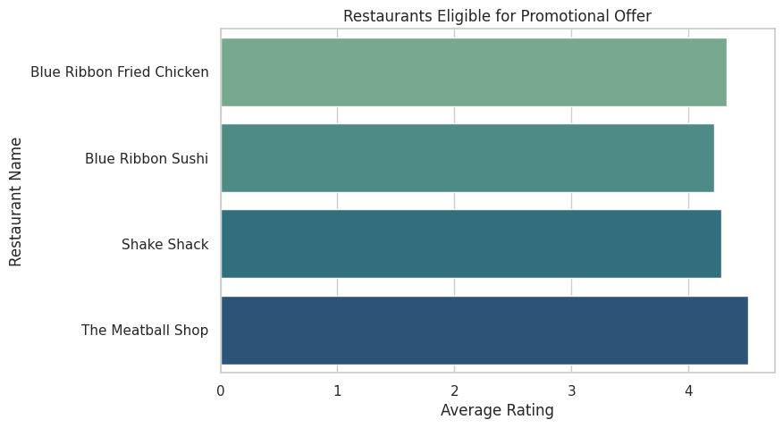

```python
# Question 13: Find restaurants eligible for promotional offer

# Criteria Condition:
#   - Restaurant must have more than 50 ratings (count > 50)
#   - Average rating must be greater than 4

# Step 1: Exclude non-numeric ratings ("Not given")
# The 'rating' column contains text values like 'Not given' along with numeric ratings.
# These need to be removed before performing numeric operations.
# filter (Filter Non-Numeric Ratings) + copy() to ensures safe modification (no warning).
df_filtered = df.loc[df['rating'] != 'Not given', ['restaurant_name', 'rating']].copy()

# Step 2: Convert the 'rating' column from string to integer
# This allows us to calculate averages and counts numerically.
df_filtered['rating'] = df_filtered['rating'].astype(int)

# Step 3: Group the dataset by 'restaurant_name' and compute:
#   - 'count' → number of ratings each restaurant received
#   - 'mean'  → average rating for each restaurant
# The result is a new DataFrame with restaurant names and their rating stats.
# Groups data by restaurant. Calculates both count (number of ratings) and mean (average rating).
restaurant_rating_stats = df_filtered.groupby('restaurant_name')['rating'].agg(['count', 'mean']).reset_index()

# Step 4: Apply the eligibility conditions for the promotional offer:
#   - count > 50 → restaurant must have more than 50 ratings
#   - mean > 4   → average rating must be greater than 4
# Filters only those restaurants with more than 50 ratings and average rating above 4.
eligible_restaurants = restaurant_rating_stats[
    (restaurant_rating_stats['count'] > 50) &
    (restaurant_rating_stats['mean'] > 4)
]

# Step 5: Display the result
print("\n Restaurants eligible for promotional offer:")
print(eligible_restaurants)

# Step 6 (Optional): Visualize eligible restaurants by their average rating
# sns.barplot() creates a horizontal bar chart showing eligible restaurants and their average ratings.
# hue='restaurant_name' ensures each restaurant has a unique color and avoids the palette deprecation warning.
plt.figure(figsize=(8,5))
sns.barplot(
    x='mean',
    y='restaurant_name',
    hue='restaurant_name',
    data=eligible_restaurants,
    palette="crest",
    legend=False
)
# Add titles and labels for clarity
plt.title('Restaurants Eligible for Promotional Offer')
plt.xlabel('Average Rating')
plt.ylabel('Restaurant Name')

# Show the plot
plt.show()
```

#### Observations for Question 13 — Restaurants Eligible for Promotional Offer

Restaurants fulfilling the promotional offer criteria:

```
1. Shake Shack — 133 ratings, Average Rating: 4.28

2. The Meatball Shop — 84 ratings, Average Rating: 4.51

3. Blue Ribbon Sushi — 73 ratings, Average Rating: 4.22

4. Blue Ribbon Fried Chicken — 64 ratings, Average Rating: 4.33
```

Insights:

1. These restaurants are both highly rated and highly reviewed, making them ideal candidates for FoodHub’s promotional advertising.
2. This approach ensures quality-driven visibility, as only restaurants with consistent customer satisfaction and engagement are featured.
3. Highlighting top performers builds customer trust and encourages other restaurants to improve their service quality to reach similar recognition.

Business Implication:

i. These top-performing restaurants can be featured in marketing campaigns and app promotions to attract new customers and reinforce FoodHub’s brand image of quality.

ii. This strategy not only rewards excellence but also motivates other restaurants to maintain high ratings and engagement for future promotional opportunities.

### **Question 14:** The company charges the restaurant 25% on the orders having cost greater than 20 dollars and 15% on the orders having cost greater than 5 dollars. Find the net revenue generated by the company across all orders. [3 marks]

```python
# Question 14: Net revenue generated by the company (without modifying original DataFrame)

# Commission logic:
#   - 25% commission on orders costing > $20
#   - 15% commission on orders costing > $5 and <= $20
#   - 0% commission on orders costing ≤ $5

# Step 1: Apply conditional commission logic using np.where()
# Instead of modifying df, store results in a separate variable 'commission'.
commission = np.where(
    df['cost_of_the_order'] > 20,
    0.25 * df['cost_of_the_order'],      # 25% for orders > $20
    np.where(
        df['cost_of_the_order'] > 5,
        0.15 * df['cost_of_the_order'],  # 15% for orders > $5 and ≤ $20
        0                                # 0% for orders ≤ $5
    )
)

# Step 2: Calculate total net revenue
# The company's revenue = sum of all commissions across all orders.
net_revenue = commission.sum()
print(f"Net revenue generated by the company across all orders: ${net_revenue:.2f}\n")

# Step 3: Sanity Check — Recalculate revenue by order groups
# This confirms that the commission logic is applied correctly.

# Group 1: High-value orders (> $20)
high_value_orders = df[df['cost_of_the_order'] > 20]

# Group 2: Mid-value orders ($5 < order ≤ $20)
mid_value_orders = df[(df['cost_of_the_order'] > 5) & (df['cost_of_the_order'] <= 20)]

# Group 3: Low-value orders (≤ $5)
low_value_orders = df[df['cost_of_the_order'] <= 5]

# Calculate revenue separately for both segments
revenue_high = (0.25 * high_value_orders['cost_of_the_order']).sum()
revenue_mid = (0.15 * mid_value_orders['cost_of_the_order']).sum()

# Combine to verify total net_revenue
net_revenue_check = revenue_high + revenue_mid

# Step 4: Sanity Check : Display revenue breakdown for validation
print("\nRevenue breakdown by order category:")
print("--------------------------------------")
print(f"1. Revenue from >$20 orders: ${revenue_high:.2f}")
print(f"2. Revenue from $5–$20 orders: ${revenue_mid:.2f}")
print(f"3. Total Net Revenue: ${net_revenue_check:.2f}")

# Step 5: Validation check — ensure both total net_revenue match
# Using np.isclose() to handle minor rounding differences
if np.isclose(net_revenue, net_revenue_check):
    print("4. Validation passed — Both total net_revenue match.")
else:
    print("4. Validation failed — total net_revenue do not match.")
```

```
Net revenue generated by the company across all orders: $6166.30


Revenue breakdown by order category:
--------------------------------------
1. Revenue from >$20 orders: $3688.73
2. Revenue from $5–$20 orders: $2477.58
3. Total Net Revenue: $6166.30
4. Validation passed — Both total net_revenue match.
```

#### Observations for Question 14 — Net Revenue Generated by the Company

1. The total net revenue generated by the company across all orders is approximately $6,166.30.
2. High-value orders (> $20$) make up about 29% of all orders but contribute nearly 60% ($3,688.73) of the total revenue.
3. Mid-value orders ($5–$20) represent around 70% of all orders and contribute about 40% ($2,477.58) of total revenue.
4. Only 9 orders (≤ $5) generate no commission, having a negligible impact on business performance.

Business Implications

1. Encourage higher-value orders: Although high-value orders are fewer, they generate the majority of total revenue. FoodHub can promote combo meals or small add-ons — for example, “Add a dessert for $3 more” — to increase the average order value.
2. Reward premium customers: High-spending customers can be retained through loyalty points, early access deals, or personalized offers to maintain engagement.
3. Maintain balanced growth: Most orders fall between ($5$–$20$) and contribute significantly to total revenue. FoodHub can introduce small discounts (e.g., “Get 10% off on orders above $15”) to encourage mid-value customers to spend slightly more.

### **Question 15:** The company wants to analyze the total time required to deliver the food. What percentage of orders take more than 60 minutes to get delivered from the time the order is placed? (The food has to be prepared and then delivered.) [2 marks]

```python
# Question 15: Percentage of orders taking more than 60 minutes in total (non-destructive)

# Step 1: Calculate total time taken per order (without adding a new column)
# Instead of saving to df['total_time'], store the result in a temporary variable.
total_time = df['food_preparation_time'] + df['delivery_time']

# Step 2: Count total number of orders in the dataset
total_orders = len(df)  # total rows

# Step 3: Count how many orders took more than 60 minutes in total
# Create a Boolean mask (True for orders > 60 minutes)
orders_above_60 = (total_time > 60).sum()  # sum() counts True values

# Step 4: Calculate the percentage of such orders
percentage_above_60 = (orders_above_60 / total_orders) * 100

# Step 5: Display results
print(f"Total Orders: {total_orders}")
print(f"Orders taking more than 60 minutes: {orders_above_60}")
print(f"Percentage of orders taking more than 60 minutes: {percentage_above_60:.2f}%")
```

```
Total Orders: 1898
Orders taking more than 60 minutes: 200
Percentage of orders taking more than 60 minutes: 10.54%
```

#### Observations for Question 15 — Total Delivery Time (> 60 Minutes)

1. Out of 1,898 total orders, 200 orders (≈10.54%) took more than 60 minutes from placement to delivery. The small percentage of delayed orders likely results from longer delivery distances, traffic conditions, or high weekend demand periods.
2. Around 89.5% of orders were completed within one hour, showing that the overall delivery process is efficient and well-managed.

Business Implications:

1. Maintain consistency: Since nearly 90% of deliveries are on time, the company should continue following the current preparation and delivery workflows that ensure quick fulfillment.
2. Reduce operational delays: Investigate the 10% of delayed orders (> 60 mins) to find patterns — for example, specific restaurants, delivery zones, or peak times. Use route optimization and demand forecasting to allocate more drivers and kitchen resources during busy hours, reducing overall delays.
3. Enhance customer experience: For customers affected by those 10% delayed deliveries, proactively send real-time ETA updates or offer small compensations/discounts. This approach helps maintain customer trust and satisfaction, even when occasional delays occur.

### **Question 16:** The company wants to analyze the delivery time of the orders on weekdays and weekends. How does the mean delivery time vary during weekdays and weekends? [2 marks]

```
Mean Delivery Time by Day Type:
-------------------------------
  day_of_the_week  delivery_time
0         Weekday      28.340037
1         Weekend      22.470022
```

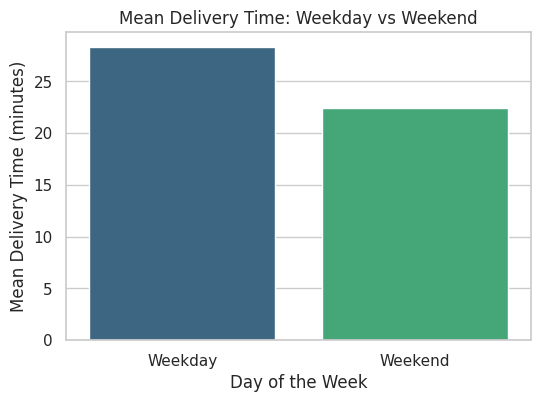

```python
# Question 16: Mean delivery time comparison between weekdays and weekends

# Step 1: Group the data by 'day_of_the_week' and calculate the average delivery time.
# The result shows the mean delivery time for each category — 'Weekday' and 'Weekend'.
mean_delivery_by_day = df.groupby('day_of_the_week')['delivery_time'].mean().reset_index()

# Step 2: Display the mean delivery time for both day types.
print("Mean Delivery Time by Day Type:")
print("-------------------------------")
print(mean_delivery_by_day)
print("\n")

# Example output:
#   day_of_the_week   delivery_time
#   Weekday           28.34
#   Weekend           22.47
# This shows deliveries are faster on weekends.

# Step 3: Visualize the difference between weekday and weekend mean delivery times.

# sns.barplot() draws bars comparing mean delivery times between weekday and weekend.
# hue='day_of_the_week' → ensures each bar gets a unique color.
# palette='viridis' → applies a nice gradient color scheme.
# legend=False → removes the redundant legend since labels already appear on X-axis.
plt.figure(figsize=(6,4))
sns.barplot(
    x='day_of_the_week',
    y='delivery_time',
    hue='day_of_the_week',
    data=mean_delivery_by_day,
    palette='viridis',
    legend=False
)

# Step 4: Add title and labels for clarity.
plt.title('Mean Delivery Time: Weekday vs Weekend')
plt.xlabel('Day of the Week')
plt.ylabel('Mean Delivery Time (minutes)')

# Step 5: Show the plot.
plt.show()
```

#### Observations for Question 16 - Mean Delivery Time (Weekday vs Weekend)

1. The average delivery time on weekdays is about 28.34 minutes, while on weekends it’s about 22.47 minutes.
2. This means that orders are delivered around 6 minutes faster on weekends compared to weekdays.
3. The faster weekend deliveries suggest lighter traffic, more available drivers, or smoother kitchen operations when demand is high but staffing is better aligned.

Business Implications:

1. Keep weekend efficiency: Maintain the same staffing and delivery practices used on weekends since they help deliver food faster.
2. Improve weekday performance: Analyze weekday bottlenecks (like traffic patterns, lunch-hour congestion, or limited staff) and use route optimization or adjusted driver shifts to close the 6-minute gap.
3. Marketing insight: Highlight faster weekend delivery times in app promotions (“Quick Weekend Deliveries — Hot & Fresh in Under 25 Minutes!”) to attract more weekend orders.

### Conclusion and Recommendations

### **Question 17:** What are your conclusions from the analysis? What recommendations would you like to share to help improve the business? (You can use cuisine type and feedback ratings to drive your business recommendations.) [6 marks]

### Question 17: Conclusions and Recommendations

### Conclusions from the Analysis

1. Customer Base & Ordering Pattern:

   a. FoodHub processed 1,898 total orders from 1,200 unique customers.

   b. About 37% of orders came from repeat customers, showing moderate loyalty but also room for improvement in customer retention.

   c. Around 63% of customers are one-time buyers, meaning many users try the service once but don’t return.

   d. However, the 37% repeat segment contributes a large portion of total orders — this highlights a strong opportunity to nurture existing customers through personalized offers, loyalty programs, and re-engagement campaigns.
2. Restaurant Performance:

   a. FoodHub hosts 178 restaurants, but 54% received three or fewer orders, showing that most restaurants have very low activity.

   b. The remaining 46% of restaurants dominate total order volume, indicating that customer demand is concentrated among a few top performers.

   d. This reflects a highly right-skewed distribution, meaning a small group of restaurants drives most of FoodHub’s business.
3. Cuisine preferences:

   b. These three cuisines dominate overall demand, showing a right-skewed distribution — a few mainstream cuisines attract most customer orders.

   c. The popularity of American cuisine remains steady across weekdays and weekends, suggesting customers consistently prefer familiar comfort foods.
4. Customer Feedback (Ratings):

   a. About 39% of customers did not provide a rating, showing that feedback participation is limited.

   c. While ratings are mostly positive, the high percentage of missing feedback suggests that FoodHub could encourage customers to share more reviews through gentle reminders or small incentives (e.g., reward points or discount coupons).
5. Operational Efficiency:

   a. Average food preparation time: ~27 minutes

   b. Average delivery time: ~24 minutes

   c. Total fulfillment time: ~51 minutes

   d. Nearly 90% of all orders are completed within one hour, showing strong operational consistency and efficient coordination between kitchens and delivery teams.

   f. Overall, both preparation and delivery processes perform reliably, with minimal delays and no major operational bottlenecks.
6. Revenue Insights:

   Company earns 15–25% commission per order, generating around $6,166 in total revenue.

   a. Around 71 % of orders happen on weekends, indicating that weekend demand drives the business.

   b. Weekday traffic is relatively low.

### Business Recommendations:

1. Strengthen Customer Retention:

   a. Launch loyalty programs or “repeat-order rewards” to encourage customers to reorder more often — especially the 37% repeat customers who already show strong engagement.

   b. Offer personalized promotions based on order history — for example, discounts on a customer’s favorite cuisine or restaurant to boost retention.

   c. Introduce referral incentives so loyal customers bring in new users, creating a sustainable cycle of growth and engagement.
2. Promote High-Performing Restaurants:

   a. Promote top restaurants such as Shake Shack (219 orders), The Meatball Shop (132 orders), and Blue Ribbon Sushi (119 orders) through targeted ads and app placements (e.g., “Top Picks” or “Recommended for You”) to maintain visibility and engagement.

   b. Use these high performers as benchmarks — analyze what they excel at (menu pricing, food quality, speed, high ratings) and share these best practices with other restaurant partners to raise overall platform quality.
3. Boost Underperforming Restaurants:

   a. Provide smaller restaurants (≈54%) with data-driven dashboards showing how they compare with top performers on key metrics — order volume, average rating, delivery time, and customer feedback — so they can identify and fix performance gaps.

   b. Offer personalized recommendations such as optimizing pricing, improving packaging, or reducing delivery delays.

   c. Run targeted promotions and visibility boosts to help these restaurants attract new customers and balance order distribution across the platform.
4. Optimize Cuisine Offerings:

   b. Onboard more restaurants serving these cuisines, especially in regions with fewer options.

   c. Launch “Discover New Cuisines” campaigns or offer discounts on niche categories (e.g., Korean, Mediterranean, Mexican) to encourage variety and expand customer preferences.

   d. Use cuisine-based weekend promotions like “Weekend Japanese Combo Deals” or “Italian Feast Fridays” to boost engagement.
5. Encourage More Customer Feedback:

   a. Since about 39% of customers skip providing ratings, introduce in-app reminders or small incentives — for example, “Rate your meal and get 10% off your next order” or earn reward points for feedback.

   b. Use customer ratings to monitor service quality trends by restaurant and cuisine type.

   c. Highlight highly rated restaurants (mostly 4★–5★) in marketing campaigns and app listings to build trust and attract more users.
6. Maintain and Enhance Delivery Efficiency:

   a. Continue following current SOPs that keep average fulfillment around 51 minutes (27 min prep + 24 min delivery) — with 90% of orders delivered within one hour.

   b. Scale weekend staffing and driver availability since 71% of total orders occur on weekends.

   c. Introduce weekend-exclusive offers (e.g., “Weekend Feast – 20% Off”) to capitalize on peak demand while maintaining fast delivery performance.
7. Data-Driven Expansion:

   a. Use geo-analytics (if available later) and order trend analysis to identify areas or time slots with consistently high demand and allocate delivery resources dynamically.

   b. Expand partnerships with top cuisines and high-rated restaurants to maximize customer satisfaction and revenue growth.